# RANDOM FOREST ALGORITHM

An analysis of the random forest algorithm and its applications in the health industry

Maddie Sortino and Jisa Jose (Advisor: Dr. Cohen)

2025-04-19

## Introduction

*Overview of Random Forest Algorithm*

- **Random Forest (RF)** is a widely used ensemble machine learning algorithm built on decision trees.
- It combines two key techniques:
  - **Bootstrapping (bagging):** Creates multiple subsets of data for training.
  - **Random feature selection:** Randomly selects features at each split to reduce correlation between trees.

## Pros & Cons

*Overview of the strengths and limitations of using Random Forest for clinical applications*

### Advantages in Healthcare:

- Handles complex, high-dimensional clinical data
- Robust against overfitting, noise, and missing data
- Flexible for both classification and regression
- Provides insights through feature importance

### Limitations:

- High computational requirements
- Longer training time with large datasets
- Lower interpretability (compared to simpler methods)
- Performance may plateau with excessive tuning

## Real World Applications

- Colon cancer survival analysis using SEER data (Rigatti 2017)
- ICU outcome prediction and sepsis risk classification (Probst, Wright, and Boulesteix 2019)
- Diabetes detection and prevention (Khine and Tun 2022)
- Medication demand forecasting (Mbonyinshuti, Nshimiyimana, and Uwitonze 2022)

## Study Objective

- Predict heart disease using Random Forest and structured clinical data
- Compare baseline model with tuned Random Forest model
- Evaluate model performance using key metrics:
  - Accuracy
  - Precision
  - Recall
  - F1 Score
  - AUC-ROC (Area under the Receiver Operating Characteristic curve)

## Method Overview

- **Step 1: Single Decision Tree (Baseline)**
  - Built a simple decision tree to establish a baseline and gain initial insights into the data
- **Step 2: Random Forest Model**
  - Improved predictions using a Random Forest with 100 decision trees
- **Step 3: Hyperparameter Tuning**
  - Optimized model performance using 5-fold cross-validation
  - Tuned the `mtry` parameter (number of features considered at each split)

## Hyperparameter Tuning Explanation

- Hyperparameters are adjustable settings that influence how the model learns from data
- In Random Forest, hyperparameters control:
  - How trees are built
  - How features are selected
  - How predictions are aggregated
- Proper tuning helps:
  - Improve predictive accuracy
  - Reduce over fitting
  - Ensure the model generalizes well, especially in sensitive fields like healthcare

## Evaluation Metrics

- **Accuracy**: Measures overall correctness of the model.
  $$Accuracy = \frac{TP + TN}{TP + TN + FP + FN}$$
- **Precision**: Measures how many predicted positives are truly positive.
  $$Precision = \frac{TP}{TP + FP}$$
- **Recall (Sensitivity)**: Measures how many actual positives were correctly identified.
  $$Recall = \frac{TP}{TP + FN}$$
- **F1 Score**: Balances precision and recall. A good measure for imbalanced datasets.
  $$F1 = \frac{2 \cdot (Precision \cdot Recall)}{Precision + Recall}$$
- **AUC-ROC**: Area under the ROC curve; shows how well the model distinguishes between classes.
  - Higher AUC means better class separation performance.

(TP = True Positive, TN = True Negative, FP = False Positive, FN = False Negative)

## Dataset Overview

- **Source**: Kaggle – Heart Failure Prediction Dataset
- **Total Records**: 918 patient entries, with 11 clinical and demographic features

### Key Features:

- **Demographic / General Clinical Features:**  
  Age, Sex, RestingBP (Resting Blood Pressure), Cholesterol, MaxHR (Maximum Heart Rate Achieved), FastingBS (Fasting Blood Sugar)
- **Cardiac-Specific Clinical Features:**  
  ChestPainType, RestingECG (Resting Electrocardiogram results), ExerciseAngina (Exercise-induced Angina), Oldpeak (ST Depression), ST_Slope (Slope of ST segment)

### Target Variable:

HeartDisease (1 = indicates heart disease, 0 = no heart disease)

*Table 1: Data Structure Overview*

Data Structure Overview

| Column | Type | values |
| --- | --- | --- |
| Age | integer | 40, 49, 37, 48, 54 |
| Sex | character | M, F, M, F, M |
| ChestPainType | character | ATA, NAP, ATA, ASY, NAP |
| RestingBP | integer | 140, 160, 130, 138, 150 |
| Cholesterol | integer | 289, 180, 283, 214, 195 |
| FastingBS | integer | 0, 0, 0, 0, 0 |
| RestingECG | character | Normal, Normal, ST, Normal, Normal |
| MaxHR | integer | 172, 156, 98, 108, 122 |
| ExerciseAngina | character | N, N, N, Y, N |
| Oldpeak | numeric | 0, 1, 0, 1.5, 0 |
| ST_Slope | character | Up, Flat, Up, Flat, Up |
| HeartDisease | integer | 0, 1, 0, 1, 0 |

## Key Insights & Observations

- **Data Quality:**
  - No missing or duplicate records
  - Some unrealistic values (e.g., cholesterol = 0) were cleaned prior to modeling
- **Gender Distribution:**
  - 79% male, 21% female
  - Potential influence on model fairness and generalization
- **Chest Pain Type:**
  - 54% of patients reported asymptomatic chest pain (ASY)
  - Indicates a high number of silent or undiagnosed cases
- **Heart Disease Distribution:**
  - 55.3% diagnosed with heart disease
  - 44.7% undiagnosed
  - Fairly balanced for effective classification

## Distribution of Features

*Figure 1: Distribution of some Features*

```r
# The distribution of 'Age' with a histogram - normal distribution
ageplot <- ggplot(data, aes(x = Age)) +
  geom_histogram(bins = 30, fill = "blue", color = "black") +
  theme_minimal() +
  theme(plot.title = element_text(hjust = 0.5)) +
  labs(title = "Age Distribution", x = "Age", y = "Count")

# The distribution of 'Heart Disease' with a histogram - no class imbalance
hdplot <- ggplot(data, aes(x = HeartDisease)) +
  geom_bar(fill = "blue", color = "black") +
  theme_minimal() +
  theme(plot.title = element_text(hjust = 0.5)) +
  scale_x_continuous(breaks=c(0,1)) +
  labs(title = "Heart Disease Class Distribution", x = "Heart Disease", y = "Count")

# The distribution of 'Sex' with a histogram - imbalance: ~4x more males than females
splot <- ggplot(data, aes(x = Sex)) +
  geom_bar(fill = "blue", color = "black") +
  theme_minimal() +
  theme(plot.title = element_text(hjust = 0.5)) +
  labs(title = "Sex Distribution", x = "Sex", y = "Count")

# The distribution of 'Cholesterol' with a histogram - over 150 records with a cholesterol of 0; otherwise normal distribution
cplot <- ggplot(data, aes(x = Cholesterol)) +
  geom_histogram(fill = "blue", color = "black") +
  theme_minimal() +
  theme(plot.title = element_text(hjust = 0.5)) +
  labs(title = "Cholesterol Distribution", x = "Cholesterol", y = "Count")

grid.arrange(hdplot, splot, ageplot, cplot, ncol = 2, nrow=2)
```

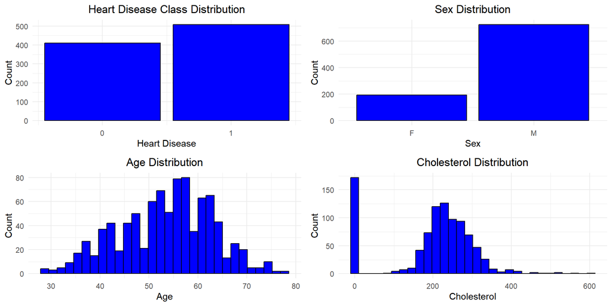

- Distribution/trends which are relevant in predicting heart diseases.

## Distribution Explanations

- **Heart Disease Distribution (Top-Left):** The distribution is appropriately balanced, minimizing the chances of bias in the model.
- **Sex Distribution (Top-Right):** The dataset has more male patients than female, which might impact predictions.
- **Age Distribution (Bottom-Left):** Most patients fall within the 40-70 years age range, which may reduce model accuracy for younger individuals.
- **Cholesterol Distribution (Bottom-Right):** The presence of zero values in cholesterol is unrealistic, indicating the need for data cleaning.

## Correlation Matrix

*Figure 2: Correlation Matrix – Understanding Key Relationships*

```r
# correlation matrix for numeric features
library(corrplot)
numeric_data <- data %>% select(where(is.numeric))
cor_matrix <- cor(numeric_data)
corrplot(cor_matrix, method = "circle", type = "upper",
         tl.col = "black", tl.cex = 0.7, addCoef.col = "black")
```

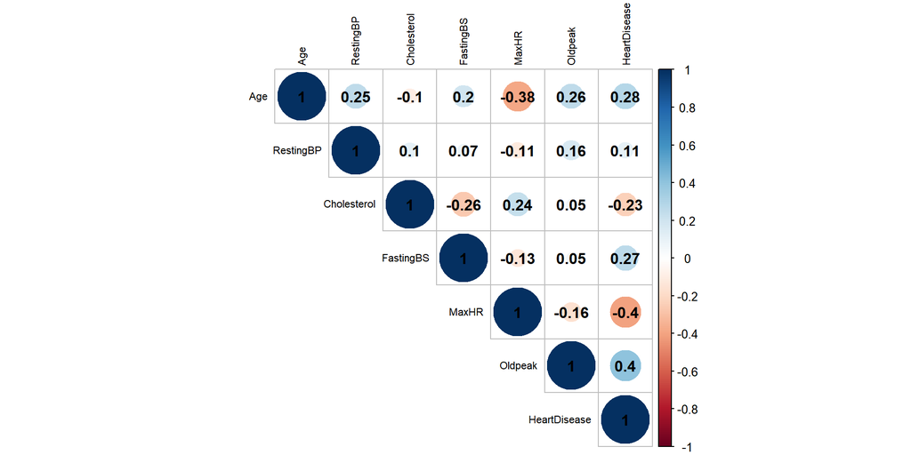

## Correlation Matrix Insights

- Figure 2 shows correlations of features in the data set with heart disease.
- Oldpeak (0.40) stands out since higher ST depression is associated with heart disease risk.
- Patients who have heart disease are more likely to have lower maximum heart rate (MaxHR (-0.40)).
- Age (0.28) and Fasting Blood Sugar (0.27) also emerged as positive correlates, confirming that older people and people with high fasting blood sugar levels are at risk.

## Modeling and Results

- Begin with performing any necessary cleaning and preprocessing of the data.
- We will then use the decision tree algorithm to demonstrate how a decision tree works, and show the performance of one tree.
- The next step will be using the random forest algorithm, which is a combination of decision trees, to see how it performs in comparison, ideally providing a more accurate prediction.

## Data Preprocessing and Cleaning

- No null or NA missing values found in the data set
- One row with a RestingBP = 0
- 172 rows with Cholesterol = 0
- We decided to drop these rows from the data set, as they were missing valid data.

## Data Encoding

- The next step is to encode the data.
- The random forest alogorithm, along with most machine learning algorithms, functions best with numerical values.
- Use one-hot encoding to transform the categorical variables into a binary column that indicates the presence (1) or absence (0) of the category.

*Encoded Data Preview*

| Age | SexF | SexM | ChestPainTypeASY | ChestPainTypeATA | ChestPainTypeNAP | ChestPainTypeTA | RestingBP | Cholesterol | FastingBS | RestingECGLVH | RestingECGNormal | RestingECGST | MaxHR | ExerciseAnginaN | ExerciseAnginaY | Oldpeak | ST_SlopeDown | ST_SlopeFlat | ST_SlopeUp | HeartDisease |
| --- | --- | --- | --- | --- | --- | --- | --- | --- | --- | --- | --- | --- | --- | --- | --- | --- | --- | --- | --- | --- |
| 40 | 0 | 1 | 0 | 1 | 0 | 0 | 140 | 289 | 0 | 0 | 1 | 0 | 172 | 1 | 0 | 0 | 0 | 0 | 1 | 0 |
| 49 | 1 | 0 | 0 | 0 | 1 | 0 | 160 | 180 | 0 | 0 | 1 | 0 | 156 | 1 | 0 | 1 | 0 | 1 | 0 | 1 |
| 37 | 0 | 1 | 0 | 1 | 0 | 0 | 130 | 283 | 0 | 0 | 0 | 1 | 98 | 1 | 0 | 0 | 0 | 0 | 1 | 0 |

## Splitting Data

- We split the data set into training and test subsets.
- The training subset will contain 70% of the data.
- The test subset will contain 30% of the data.

## Model Fitting and Prediction

**Decision Tree**

- We first demonstrate how a single decision tree would look for our data set.
- We achieved an accuracy of 81.7% without hyperparameter tuning.
- The decision tree can be followed to determine what the predicted end result would be.
- For example, if the patient has ST_SlopeUp = 1 and ChestPainTypeASY = 0; they likely do not have heart disease. If the patient has ST_SlopeUp = 0, MaxHR < 151, SexF = 0, then the patient likely does have heart disease.

## Decision Tree

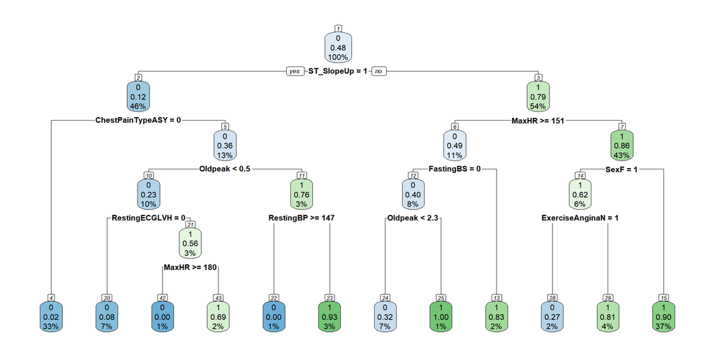

## Random Forest

- After gaining an understanding of how a single decision tree functions; we proceed with the bulk of our analysis using the random forest algorithm.
- We trained the random forest using 100 trees and graphed the decision tree and evaluation metrics below. The random forest achieved an accuracy of 88.4%, which is higher than the 81.7% obtained from the single decision tree, as expected.
- The confusion matrix shows that there were 104 true negatives (HeartDisease=0), 94 true positives (HeartDisease=1), 13 false negatives, and 13 false positives. Precision, recall, sensitivity, and F1 scores were all the same.

## Confusion Matrix - Default

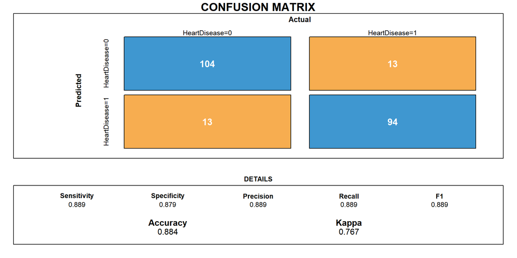

## Confusion Matrix - Tuned Model

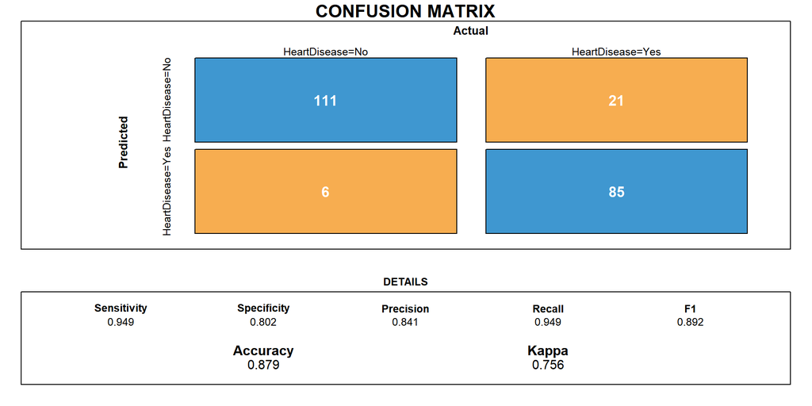

## Area Under Curve

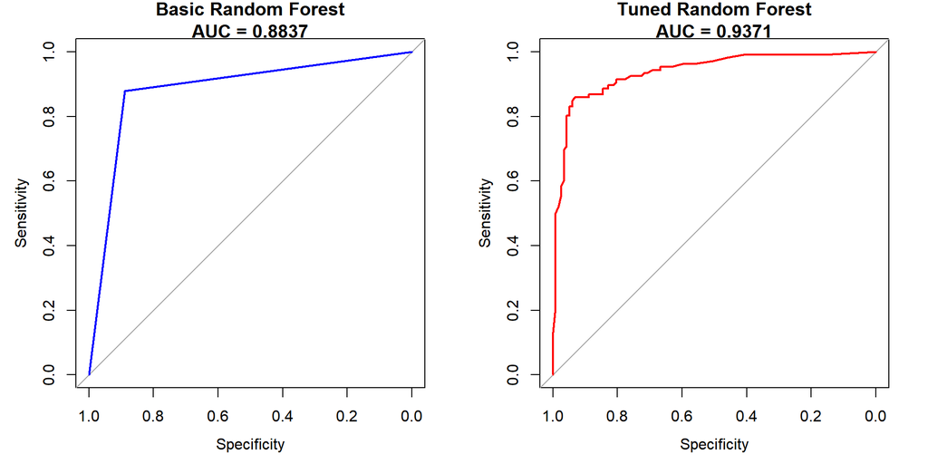

(Figure 6: ROC curve with an AUC score of both basic RF Model & tuned RF Model)

## Feature Importance

- We also looked for feature importance, which showed ST_SlopeUp, ChestPainTypeASY, and ST_SlopeFlat to be some of the most important predictors.
- This is consistent with medical domain knowledge since changes in ST segments and chest pain types are known markers of cardiac abnormality (Khalilia, Chakraborty, and Popescu 2011).
- The model’s ability to capture meaningful physiological patterns is also supported by the high ranking of MaxHR and Oldpeak.

## Feature Importance

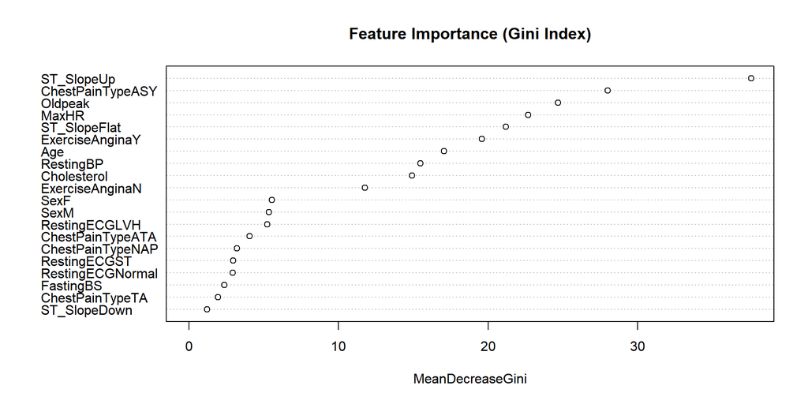

(Figure 7. Feature importance based on the average decrease in Gini index.)

## References

Fawcett, Tom. 2006. “An Introduction to ROC Analysis.” *Pattern Recognition Letters* 27 (8): 861–74. https://doi.org/10.1016/j.patrec.2005.10.010.

Khalilia, Mohammed, Sounak Chakraborty, and Mihail Popescu. 2011. “Predicting Disease Risks from Highly Imbalanced Data Using Random Forest.” *BMC Medical Informatics and Decision Making* 11: 1–13. https://doi.org/10.1186/1472-6947-11-51.

Khine, Wai Wai, and Zaw Tun. 2022. “Diabetes Prediction Based on Machine Learning Algorithms: MNB, Random Forest, SVM.” *IEEE Access*.

Mbonyinshuti, François, Jean Nshimiyimana, and Claude Uwitonze. 2022. “Application of Random Forest Model to Predict the Demand of Essential Medicines for Non-Communicable Diseases Management in Public Health Facilities.” *Pan African Medical Journal* 42: 89.

Oshiro, Thais Mayumi, Pedro Santoro Perez, and José Augusto Baranauskas. 2012. “How Many Trees in a Random Forest?” In *Machine Learning and Data Mining in Pattern Recognition: 8th International Conference, MLDM 2012, Berlin, Germany, July 13-20, 2012. Proceedings 8*, 154–68. Springer. https://doi.org/10.1007/978-3-642-31537-4_13.

Probst, Philipp, Marvin N. Wright, and Anne-Laure Boulesteix. 2019. “Random Forest Algorithms in Health Care Sectors: A Review of Applications.” *Wiley Interdisciplinary Reviews: Data Mining and Knowledge Discovery* 9 (3): e1301.

Rigatti, Steven J. 2017. “Random Forest.” *Journal of Insurance Medicine* 47 (1): 31–39. https://doi.org/10.17849/insm-47-01-31-39.1.